# Curso R: Programação em R (Nível Básico)

02 março, 2021

## Encarte

[figure not shown]

## Agradecimentos

[figure not shown]

[figure not shown]

## Agradecimentos

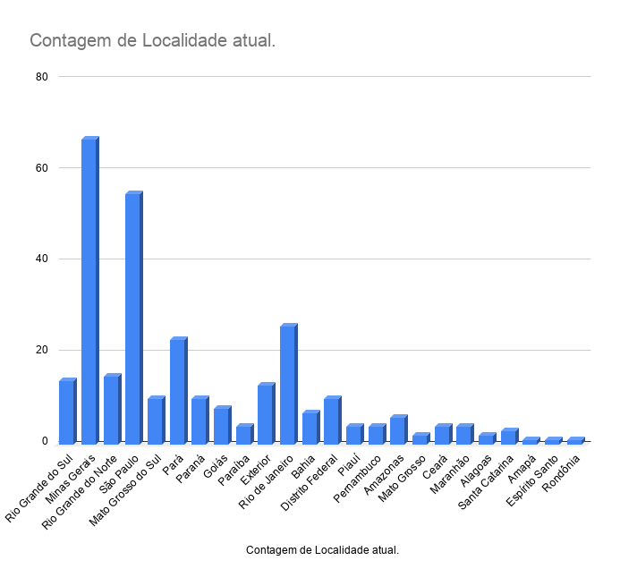

## Objetivo do curso

- O curso R **não** tem como objetivo principal de **ensinar análise de dados**.
- Mas **sim**, proporcionar a você um **conhecimento sobre a linguagem R** (sintaxe e semântica), de modo que consiga usufruir todos os recursos que ela possa lhe proporcionar.

## Ementa do curso

- site: http://bendeivide.github.io/cursor
- Ementa: http://bendeivide.github.io/cursor/nbasico.html#slidesaulas

## Materiais para o curso

- site: http://bendeivide.github.io/cursor
- Aulas de apresentação: http://bendeivide.github.io/cursor/nbasico.html#slidesaulas
- *Scripts*: http://bendeivide.github.io/cursor/nbasico.html#scripts
- *Scripts* via [Shiny](https://shiny.rstudio.com/): http://bendeivide.github.io/cursor/nbasico.html#shiny
- Vídeo-aulas:
  - http://youtube.com/bendeivide
  - [Playlist Curso R: Programação em R (Nível Básico)](https://www.youtube.com/playlist?list=PL-20Z1XFWKR0y0qZdOM0KKqb4oEbAMs7O)

## Referências utilizadas

- Referências: http://bendeivide.github.io/cursor/index.html#referencias

## Programação

- A divulgação das vídeo-aulas ocorrerão sempre às quintas-feiras, às 20h;
- Cada vídeo publicado, vocês receberão um email de informação;
- Começaremos dia 18/02/2021;
- Todos os vídeos terão curta duração, para que ao final, o estudo se torne mais eficiente;
- O curso terá duração de cinco semanas (18/02/2021 - 18/03/2021);
- Para cada semana disponibilizaremos entre 4 a 6 vídeos;
- Nos dias 03/03/2021 e 17/03/2021, das 19h às 20h, aulas ao vivo no canal, para as dúvidas, de acordo com o conteúdo abordado;
- A emissão dos certificados serão disponibilizados para os inscritos que tiverem frequência em 80% das aulas;
- A frequência de cada aula estará disponível no chat/descrição do vídeo, durante uma semana, contados a partir da data da publicação do vídeo.

## Bons estudos!

[figure not shown]